# Chapter 3 Exercises

From *An Introduction to Statistical Learning with Applications in R

Jacob Zeiher

May 24, 2018

# Conceptual

## Problem 1

The $p$ values given in Table 3.4 refer to the highest level of confidence with which we can reject the null hypothesis that $\beta_i = 0, i=0,1,2,3$ where $\beta_i$ is the coefficient on intercept, TV, radio, and newspaper, respectively. From these p-values, we can conclude that intercept, TV, and radio all have a significant relationship with the outcome variables, holding the other variables constant. Since the coefficient on newspaper has a p-value of $0.8599$ there is not a significant relationship between newspaper and the outcome variable.

## Problem 2

The KNN classifier is a classification method while the KNN regression is a regression method. The KNN classifier makes a classification based on the classification of the K closest data points. Similarly, the KNN regression assigns a predicted value based on the average value of the K nearest data points. Hence, the outcome variable for the KNN classifier is categorical while the outcome variable for the KNN regression is quantitative.

## Problem 3

### Part a

We have
$$\hat{Y} = \hat{\beta_0} + \hat{\beta_1}GPA + \hat{\beta_2}IQ + \hat{\beta_3}FEMALE + \hat{\beta_4}\left(GPA \times IQ\right) + \hat{\beta_5}\left(GPA \times FEMALE\right).$$
For males this equation becomes
$$\hat{Y} = \hat{\beta_0} + \hat{\beta_1}GPA + \hat{\beta_2}IQ + \hat{\beta_4}\left(GPA \times IQ\right) = 50+20GPA+0.07IQ+0.01\left(GPA \times IQ\right),$$
and for females it becomes
$$\hat{Y} = \left(\hat{\beta_0}+\hat{\beta_3}\right) + \left(\hat{\beta_1}+\hat{\beta_5}\right)GPA + \hat{\beta_2}IQ + \hat{\beta_4}\left(GPA \times IQ\right)=85+10GPA++0.07IQ+0.01\left(GPA \times IQ\right).$$
Hence, option ii is correct: *For a fixed value of IQ and GPA, males earn more on average than females provided that the GPA is high enough.*

### Part c

False. To determine statistical significance, we need to compare $t = \frac{\hat{\beta}}{se\hat{\beta}}$ to a t-distribution with $n-2$ degrees of freedom. We cannot determine statistical significance based solely on the *magnitude* of the coefficient. We must also take into consideration its estimated standard error.

## Problem 4

### Part b

If the additional predictors lead to overfitting, the testing RSS could be worse (higher) for the cubic regression fit

### Part c

The cubic regression fit should produce a better RSS on the training set because it can adjust for the non-linearity.

### Part d

Similar to training RSS, the cubic regression fit should produce a better RSS on the testing set because it can adjust for the non-linearity.

## Problem 5

We have
$$\hat{y}_i=x_i\frac{\sum_{j=1}^nx_jy_j}{\sum_{k=1}^nx_k^2}=\sum_{j=1}^n\frac{x_jy_jx_i}{\sum_{k=1}^nx_k^2}=\sum_{j=1}^n\frac{x_jx_i}{\sum_{k=1}^nx_k^2}y_j,$$
so
$$a_j=\frac{x_ix_j}{\sum_{k=1}^nx_k^2}.$$

## Problem 6

Note that $\bar{y}=\frac{1}{n}\sum y_i=\frac{1}{n}\sum (\hat{y}_i+\hat{\epsilon}_i)$. The estimates of $\hat{y}_i$ are given by
$$\hat{y}_i = \hat{\beta_0} + \hat{\beta_1}x_{i} + \hat{\epsilon}_i.$$
Multiplying both sides by $\frac{1}{n}$ and summing from $i=1,\ldots,n$, we get
$$\frac{1}{n}\hat{y}_i = \bar{y} = \frac{1}{n} \sum (\hat{\beta_0} + \hat{\beta_1}x_{i} + \hat{\epsilon}_i) = \hat{\beta_0} + \hat{\beta_1}\bar{x},$$
where the $\hat{\epsilon}_i$ sum to $0$. Hence, $\bar{y}=\hat{\beta_0} + \hat{\beta_1}\bar{x},$ so the regression equation passes through $(\bar{x},\bar{y})$.

## Problem 7

First, show that in simple linear regression,
$$\begin{equation}\sum_{i=1}^n(y_i - \bar{y})^2 = \sum_{i=1}^n(y_i-\hat{y}_i)^2 + \sum_{i=1}^n(\hat{y}_i - \bar{y})^2.\end{equation}$$
Obviously,
$$(y_i - \bar{y}) = (y_i + \hat{y}_i) + (\hat{y}_i - \bar{y}).$$
Summing the square of both sides over all observations,
$$\sum_{i=1}^n(y_i - \bar{y})^2 = \sum_{i=1}^n(y_i-\hat{y}_i)^2 + \sum_{i=1}^n(\hat{y}_i - \bar{y})^2 + \sum_{i=1}^n2(y_i-\hat{y}_i)(\hat{y}_i - \bar{y}).$$
Need to show
$$\sum_{i=1}^n2(y_i-\hat{y}_i)(\hat{y}_i - \bar{y})=0.$$
In simple linear regression,
$$\hat{y}_i = \hat{\alpha} + \hat{\beta}x_i,$$
$$\bar{y} = \hat{\alpha} + \hat{\beta}\bar{x},$$
and
$$\hat{\beta} = \frac{\sum_{i=1}^n(x_i - \bar{x})(y_i-\bar{y})}{\sum_{i=1}^n(x_i - \bar{x})^2}.$$
Then
$$\hat{y}_i - \bar{y} = (\hat{\alpha} + \hat{\beta}x_i) - (\hat{\alpha}+\hat{\beta}\bar{x}) = \hat{\beta}(x_i - \bar{x}),$$
and
$$y_i - \hat{y}_i = (y_i - \bar{y}) - (\hat{y}_i - \bar{y}) = (y_i - \bar{y}) - \hat{\beta}(x_i-\bar{x}).$$
Then we have
$$\begin{align*}
\sum_{i=1}^n2(\hat{y}_i - \bar{y})(y_i - \hat{y}_i) &= 2\hat{\beta}\sum_{i=1}^n(x_i-\bar{x})(y_i-\hat{y}_i)\\
&= 2\hat{\beta}\sum_{i=1}^n(x_i-\bar{x})[(y_i - \bar{y}) - \hat{\beta}(x_i-\bar{x})]\\
&= 2\hat{\beta}\left[\sum_{i=1}^n(x_i-\bar{x})(y_i - \bar{y}) - \sum_{i=1}^n\hat{\beta}(x_i-\bar{x})^2\right]\\
&= 2\hat{\beta}\left[\sum_{i=1}^n(x_i-\bar{x})(y_i - \bar{y}) - \sum_{i=1}^n\left[(x_i-\bar{x})^2\sum_{j=1}^n\frac{(x_j - \bar{x})(y_j-\bar{y})}{(x_j - \bar{x})^2}\right] \right]\\
&= 2\hat{\beta}\left[\sum_{i=1}^n(x_i-\bar{x})(y_i - \bar{y}) - \sum_{i=1}^n(x_i-\bar{x})(y_i-\bar{y}) \right]\\
&= 2\hat{\beta}(0) = 0.
\end{align*}$$

Hence, (1) holds in simple linear regression.

Now need to show that
$$\begin{equation}R^2=\mathrm{Cov}^2(X,Y).\end{equation}$$
By (1) we have that
$$\begin{align}
R^2 &= \frac{TSS-RSS}{TSS}\\
&= \frac{\sum_{i=1}^n(y_i - \bar{y})^2 - \sum_{i=1}^n(y_i-\hat{y}_i)^2}{\sum_{i=1}^n(y_i - \bar{y})^2}\\
&= \frac{\sum_{i=1}^n(\hat{y}_i - \bar{y})^2}{\sum_{i=1}^n(y_i - \bar{y})^2}.
\end{align}$$
Since $\bar{y} = \hat{\alpha}+\hat{\beta}\bar{x}$, we have $\hat{\alpha} = \bar{y} - \hat{\beta}\bar{x}$. Then
$$\begin{align*}
\sum_{i=1}^n(\hat{y}_i-\bar{y})^2 &= \sum_{i=1}^n(\hat{\alpha}+\hat{\beta}x_i - \bar{y})^2\\
&= \sum_{i=1}^n(\bar{y}-\hat{\beta}\bar{x}+\hat{\beta}x_i - \bar{y})^2\\
&= \sum_{i=1}^n(\hat{\beta}(x_i - \bar{x})^2\\
&= \hat{\beta}^2 \sum_{i=1}^n(x_i - \bar{x})^2\\
&= \frac{\left[\sum_{i=1}^n(x_i-\bar{x})(y_i-\bar{y})\right]^2 \sum_{i=1}^n(x_i-\bar{x})^2}{\left[\sum_{i=1}^n(x_i-\bar{x})^2\right]^2}\\
&= \frac{\left[\sum_{i=1}^n(x_i-\bar{x})(y_i-\bar{y})\right]^2}{\sum_{i=1}^n(x_i-\bar{x})^2}.
\end{align*}$$
Then (5) becomes
$$\begin{align*}
R^2 &= \frac{\sum_{i=1}^n(\hat{y}_i - \bar{y})^2}{\sum_{i=1}^n(y_i - \bar{y})^2}\\
&= \frac{\left[\sum_{i=1}^n(x_i-\bar{x})(y_i-\bar{y})\right]^2}{\sum_{i=1}^n(x_i-\bar{x})^2 \sum_{i=1}^n(y_i - \bar{y})^2}\\
&= \left[\frac{\sum_{i=1}^n(x_i-\bar{x})(y_i-\bar{y})}{\sqrt{\sum_{i=1}^n(x_i-\bar{x})^2}\sqrt{\sum_{i=1}^n(y_i - \bar{y})^2}}\right]^2\\
&= \mathrm{Cov}^2(X,Y).
\end{align*}$$

# Applied

## Problem 8

### Part a

```r
#Import libraries
  library(ISLR)
#Fit regression
  lm.fit1 <- lm(mpg~horsepower, data=Auto)
  summary(lm.fit1)
```

```
##
## Call:
## lm(formula = mpg ~ horsepower, data = Auto)
##
## Residuals:
##      Min       1Q   Median       3Q      Max
## -13.5710  -3.2592  -0.3435   2.7630  16.9240
##
## Coefficients:
##              Estimate Std. Error t value Pr(>|t|)
## (Intercept) 39.935861   0.717499   55.66   <2e-16 ***
## horsepower  -0.157845   0.006446  -24.49   <2e-16 ***
## ---
## Signif. codes:  0 '***' 0.001 '**' 0.01 '*' 0.05 '.' 0.1 ' ' 1
##
## Residual standard error: 4.906 on 390 degrees of freedom
## Multiple R-squared:  0.6059, Adjusted R-squared:  0.6049
## F-statistic: 599.7 on 1 and 390 DF,  p-value: < 2.2e-16
```

1. Since an F-statistics of 599.7 on 1 and 390 degrees of freedom has p-value of <2.2e-16, we can reject the null hypothesis of no relationship between the response and predictor and conclude there is a relationship.
2. The model has an $R^2$ of 0.6059, so we can conclude there is a pretty strong relationship between the response and predictors. Recall that the $R^2$ is interpreted as the amount of variation in the response variable (in this case mpg) that is explained by the model.
3. Since the coefficient on horsepower is negative, the relationship between the predictor and response variable is negative. That is, as horsepower increase, mpg will decrease, on average.

```r
predict(lm.fit1,data.frame(horsepower=98),interval="confidence")
```

```
##        fit      lwr      upr
## 1 24.46708 23.97308 24.96108
```

```r
predict(lm.fit1,data.frame(horsepower=98),interval="prediction")
```

```
##        fit     lwr      upr
## 1 24.46708 14.8094 34.12476
```

### Part b

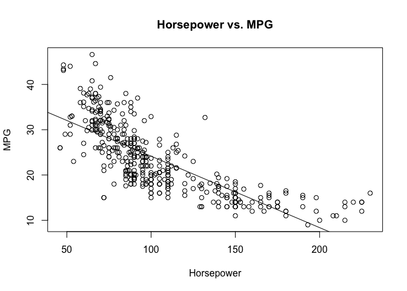

```r
#Plot regression with fit
  plot(Auto$horsepower,Auto$mpg,ylab="MPG",xlab="Horsepower",main="Horsepower vs. MPG")
  abline(lm.fit1)
```

### Part c

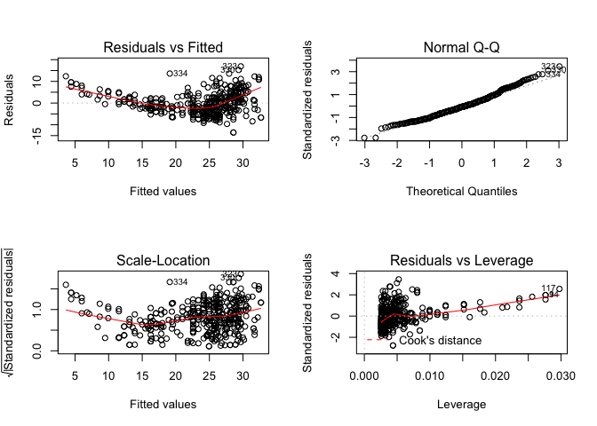

```r
#Plot regression diagnostics
  par(mfrow=c(2,2))
  plot(lm.fit1)
```

The plots of horsepower vs. mpg and the plot of residual vs fitted values both indicate there is some non-linearity in the data. The plot of standardized residuals vs leverage indicate there are some outliers and high leverage points.

## Problem 9

### Part a

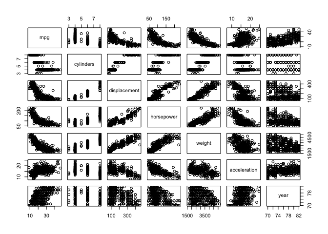

```r
#Import library
  library(ISLR)
#Produce scatterplot matrix
  pairs(Auto[1:7])
```

### Part b

```r
#Produce correlation matrix
  cor(Auto[1:8])
```

```
##                     mpg  cylinders displacement horsepower     weight
## mpg           1.0000000 -0.7776175   -0.8051269 -0.7784268 -0.8322442
## cylinders    -0.7776175  1.0000000    0.9508233  0.8429834  0.8975273
## displacement -0.8051269  0.9508233    1.0000000  0.8972570  0.9329944
## horsepower   -0.7784268  0.8429834    0.8972570  1.0000000  0.8645377
## weight       -0.8322442  0.8975273    0.9329944  0.8645377  1.0000000
## acceleration  0.4233285 -0.5046834   -0.5438005 -0.6891955 -0.4168392
## year          0.5805410 -0.3456474   -0.3698552 -0.4163615 -0.3091199
## origin        0.5652088 -0.5689316   -0.6145351 -0.4551715 -0.5850054
##              acceleration       year     origin
## mpg             0.4233285  0.5805410  0.5652088
## cylinders      -0.5046834 -0.3456474 -0.5689316
## displacement   -0.5438005 -0.3698552 -0.6145351
## horsepower     -0.6891955 -0.4163615 -0.4551715
## weight         -0.4168392 -0.3091199 -0.5850054
## acceleration    1.0000000  0.2903161  0.2127458
## year            0.2903161  1.0000000  0.1815277
## origin          0.2127458  0.1815277  1.0000000
```

### Part c

```r
#Convert origin variable into factor
  Auto$origin <- factor(Auto$origin, levels=c(1,2,3),labels=c("American","European","Japanese"))
#Fit multiple linear regression model
  lm.fit1 <- lm(mpg~.-name, data=Auto)
  summary(lm.fit1)
```

```
##
## Call:
## lm(formula = mpg ~ . - name, data = Auto)
##
## Residuals:
##     Min      1Q  Median      3Q     Max
## -9.0095 -2.0785 -0.0982  1.9856 13.3608
##
## Coefficients:
##                  Estimate Std. Error t value Pr(>|t|)
## (Intercept)    -1.795e+01  4.677e+00  -3.839 0.000145 ***
## cylinders      -4.897e-01  3.212e-01  -1.524 0.128215
## displacement    2.398e-02  7.653e-03   3.133 0.001863 **
## horsepower     -1.818e-02  1.371e-02  -1.326 0.185488
## weight         -6.710e-03  6.551e-04 -10.243  < 2e-16 ***
## acceleration    7.910e-02  9.822e-02   0.805 0.421101
## year            7.770e-01  5.178e-02  15.005  < 2e-16 ***
## originEuropean  2.630e+00  5.664e-01   4.643 4.72e-06 ***
## originJapanese  2.853e+00  5.527e-01   5.162 3.93e-07 ***
## ---
## Signif. codes:  0 '***' 0.001 '**' 0.01 '*' 0.05 '.' 0.1 ' ' 1
##
## Residual standard error: 3.307 on 383 degrees of freedom
## Multiple R-squared:  0.8242, Adjusted R-squared:  0.8205
## F-statistic: 224.5 on 8 and 383 DF,  p-value: < 2.2e-16
```

### Part d

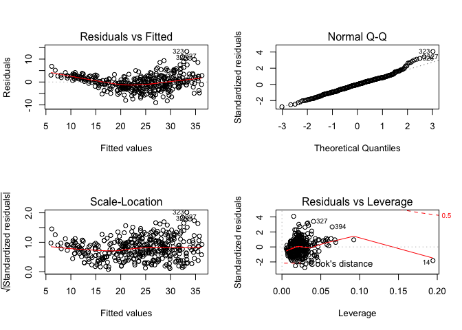

```r
#Plot regression diagnostics
  par(mfrow=c(2,2))
  plot(lm.fit1)
```

The regression diagnostic plots indicate the presence of some outliers, in particular observations 323, 327, and 326. The plots also indicate the presence of a high leverage point in observation 14.

### Part e

```r
#Fit multiple linear regression model with interaction terms
  lm.fit2 <- lm(mpg~.-name+cylinders:displacement+cylinders:horsepower, data=Auto)
  summary(lm.fit2)
```

```
##
## Call:
## lm(formula = mpg ~ . - name + cylinders:displacement + cylinders:horsepower,
##     data = Auto)
##
## Residuals:
##     Min      1Q  Median      3Q     Max
## -9.0246 -1.6646 -0.0235  1.3480 11.8755
##
## Coefficients:
##                          Estimate Std. Error t value Pr(>|t|)
## (Intercept)            11.1039607  5.0443246   2.201 0.028315 *
## cylinders              -4.2385487  0.4618816  -9.177  < 2e-16 ***
## displacement           -0.0006610  0.0177105  -0.037 0.970245
## horsepower             -0.3086123  0.0419368  -7.359 1.15e-12 ***
## weight                 -0.0040492  0.0006376  -6.351 6.10e-10 ***
## acceleration           -0.1644937  0.0935930  -1.758 0.079628 .
## year                    0.7515100  0.0460129  16.333  < 2e-16 ***
## originEuropean          1.4429494  0.5273240   2.736 0.006503 **
## originJapanese          1.8105669  0.5228537   3.463 0.000595 ***
## cylinders:displacement  0.0002336  0.0025871   0.090 0.928089
## cylinders:horsepower    0.0391074  0.0059838   6.535 2.04e-10 ***
## ---
## Signif. codes:  0 '***' 0.001 '**' 0.01 '*' 0.05 '.' 0.1 ' ' 1
##
## Residual standard error: 2.931 on 381 degrees of freedom
## Multiple R-squared:  0.8626, Adjusted R-squared:  0.859
## F-statistic: 239.2 on 10 and 381 DF,  p-value: < 2.2e-16
```

The interaction between cylinders and horsepower appears to be highly significant.

### Part f

```r
#Fit multiple linear regression model with transformation
  lm.fit3 <- lm(mpg~horsepower+I(horsepower^2), data=Auto)
  summary(lm.fit3)
```

```
##
## Call:
## lm(formula = mpg ~ horsepower + I(horsepower^2), data = Auto)
##
## Residuals:
##      Min       1Q   Median       3Q      Max
## -14.7135  -2.5943  -0.0859   2.2868  15.8961
##
## Coefficients:
##                   Estimate Std. Error t value Pr(>|t|)
## (Intercept)     56.9000997  1.8004268   31.60   <2e-16 ***
## horsepower      -0.4661896  0.0311246  -14.98   <2e-16 ***
## I(horsepower^2)  0.0012305  0.0001221   10.08   <2e-16 ***
## ---
## Signif. codes:  0 '***' 0.001 '**' 0.01 '*' 0.05 '.' 0.1 ' ' 1
##
## Residual standard error: 4.374 on 389 degrees of freedom
## Multiple R-squared:  0.6876, Adjusted R-squared:  0.686
## F-statistic:   428 on 2 and 389 DF,  p-value: < 2.2e-16
```

The coefficient on the square of the horsepower variable indicates nonlinearity in the relationship between horsepower and mpg.

## Problem 10

### Part a

```r
#Import library
  library(ISLR)
#Fit multiple regression model
  lm.fit1 <- lm(Sales~Price+Urban+US, data=Carseats)
  summary(lm.fit1)
```

```
##
## Call:
## lm(formula = Sales ~ Price + Urban + US, data = Carseats)
##
## Residuals:
##     Min      1Q  Median      3Q     Max
## -6.9206 -1.6220 -0.0564  1.5786  7.0581
##
## Coefficients:
##              Estimate Std. Error t value Pr(>|t|)
## (Intercept) 13.043469   0.651012  20.036  < 2e-16 ***
## Price       -0.054459   0.005242 -10.389  < 2e-16 ***
## UrbanYes    -0.021916   0.271650  -0.081    0.936
## USYes        1.200573   0.259042   4.635 4.86e-06 ***
## ---
## Signif. codes:  0 '***' 0.001 '**' 0.01 '*' 0.05 '.' 0.1 ' ' 1
##
## Residual standard error: 2.472 on 396 degrees of freedom
## Multiple R-squared:  0.2393, Adjusted R-squared:  0.2335
## F-statistic: 41.52 on 3 and 396 DF,  p-value: < 2.2e-16
```

### Part b

- Coefficient on price: for a unit increase in the price of the carseat, sales will decrease by $0.05*1000 = 50$, on average.
- Coefficient on Urban: being sold in an urban area decreases the carseat’s sales by $0.02*1000 = 20$, on average.
- Coefficient on US: being sold in the United States increases the carseat’s sales by 1200, on average.

### Part c

The model in equation form:
$$sales_i = \beta_0 + \beta_1 price_i + \beta_2 Urban_i + \beta_3 US_i + \epsilon_i.$$

### Part d

We can reject the null hypothesis that $\beta_j=0$ for the intercept, price, and US.

### Part e

```r
#Fit smaller multiple regression model
  lm.fit2 <- lm(Sales~Price+US, data=Carseats)
  summary(lm.fit2)
```

```
##
## Call:
## lm(formula = Sales ~ Price + US, data = Carseats)
##
## Residuals:
##     Min      1Q  Median      3Q     Max
## -6.9269 -1.6286 -0.0574  1.5766  7.0515
##
## Coefficients:
##             Estimate Std. Error t value Pr(>|t|)
## (Intercept) 13.03079    0.63098  20.652  < 2e-16 ***
## Price       -0.05448    0.00523 -10.416  < 2e-16 ***
## USYes        1.19964    0.25846   4.641 4.71e-06 ***
## ---
## Signif. codes:  0 '***' 0.001 '**' 0.01 '*' 0.05 '.' 0.1 ' ' 1
##
## Residual standard error: 2.469 on 397 degrees of freedom
## Multiple R-squared:  0.2393, Adjusted R-squared:  0.2354
## F-statistic: 62.43 on 2 and 397 DF,  p-value: < 2.2e-16
```

### Part f

Both models fit the data about the same. They both have an $R^2$ of 0.2393, but the smaller model has a higher adjusted $R^2$. Moreover, the smaller model has a slighly higher $F$-statistic and a slightly smaller RSE. All these facts indicate the smaller model fits the data slightly better than the original model.

### Part g

```r
#Confidence intervals for coefficients
  confint(lm.fit2)
```

```
##                   2.5 %      97.5 %
## (Intercept) 11.79032020 14.27126531
## Price       -0.06475984 -0.04419543
## USYes        0.69151957  1.70776632
```

### Part h

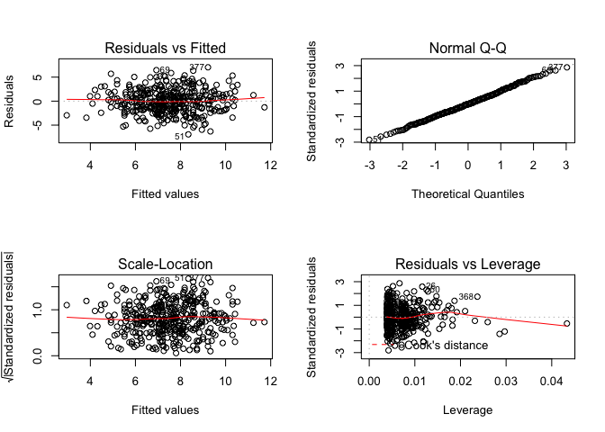

```r
#Plot regression diagnostics
  par(mfrow=c(2,2))
  plot(lm.fit2)
```

## Problem 11

### Part a

```r
set.seed(1)
x <- rnorm(100)
y <- 2*x+rnorm(100)
#Fit simple linear regression of y onto x without intercept
  lm.fit1 <- lm(y~x+0)
  summary(lm.fit1)
```

```
##
## Call:
## lm(formula = y ~ x + 0)
##
## Residuals:
##     Min      1Q  Median      3Q     Max
## -1.9154 -0.6472 -0.1771  0.5056  2.3109
##
## Coefficients:
##   Estimate Std. Error t value Pr(>|t|)
## x   1.9939     0.1065   18.73   <2e-16 ***
## ---
## Signif. codes:  0 '***' 0.001 '**' 0.01 '*' 0.05 '.' 0.1 ' ' 1
##
## Residual standard error: 0.9586 on 99 degrees of freedom
## Multiple R-squared:  0.7798, Adjusted R-squared:  0.7776
## F-statistic: 350.7 on 1 and 99 DF,  p-value: < 2.2e-16
```

According to the summary, we have $\hat{\beta}=1.9939$, $se(\hat{\beta})=0.1065$, a $t$-statistic of 18.73, and a $p$-value of $<2e-16$. These results allow us to reject the null hypothesis that $\beta=0$.

### Part b

```r
#Fit simple linear regression of x onto y without intercept
  lm.fit2 <- lm(x~y+0)
  summary(lm.fit2)
```

```
##
## Call:
## lm(formula = x ~ y + 0)
##
## Residuals:
##     Min      1Q  Median      3Q     Max
## -0.8699 -0.2368  0.1030  0.2858  0.8938
##
## Coefficients:
##   Estimate Std. Error t value Pr(>|t|)
## y  0.39111    0.02089   18.73   <2e-16 ***
## ---
## Signif. codes:  0 '***' 0.001 '**' 0.01 '*' 0.05 '.' 0.1 ' ' 1
##
## Residual standard error: 0.4246 on 99 degrees of freedom
## Multiple R-squared:  0.7798, Adjusted R-squared:  0.7776
## F-statistic: 350.7 on 1 and 99 DF,  p-value: < 2.2e-16
```

### Part c

We obtain the same $p$-value in both regression. This reflects the fact that the data come from the same line. We can write $Y=2X+\epsilon$ as $X=\frac{1}{2}(Y-\epsilon)$.

### Part d

To show algebraicly, note that
$$\begin{align*}
t &= \frac{\hat{\beta}}{se(\hat{\beta})}\\
&= \frac{\frac{\sum x_iy_i}{\sum x_i^2}}{\sqrt{\frac{\sum (y_i-x_i\hat{\beta})^2}{(n-1)\sum x_i^2}}}\\
&= \frac{\sqrt{n-1}\sum x_iy_i}{\sqrt{\sum x_i^2}\sqrt{\sum (y_i-x_i\hat{\beta})^2}}\\
&= \frac{\sqrt{n-1}\sum x_iy_i}{\sqrt{\sum x_i^2\sum y_i^2 - \sum x_i^2 \hat{\beta}\left(2\sum x_iy_i - \hat{\beta}\sum x_i^2\right)}}\\
&= \frac{\sqrt{n-1}\sum x_iy_i}{\sqrt{\sum x_i^2\sum y_i^2 - \sum x_iy_i \left(2\sum x_iy_i - \sum x_iy_i\right)}}\\
&= \frac{\sqrt{n-1}\sum x_iy_i}{\sqrt{\sum x_i^2\sum y_i^2 - \left(\sum x_iy_i\right)^2}}.
\end{align*}$$

```r
#Numerically verify above equation
  n <- length(x)
  t <- sqrt(n - 1)*(x %*% y)/sqrt(sum(x^2) * sum(y^2) - (x %*% y)^2)
  as.numeric(t)
```

```
## [1] 18.72593
```

This is the exact same $t$-value as in the previous two regressions.

### Part e

From the previous equation, we see the formula for the $t$-statistic is symmetric with respect to the ordering of $x$ and $y$. That is, we can swap the value of $x$ and $y$ in the above equation and the equation remains the same. Hence, for the $t$-statistic for $x~y$ is the same as the $t$-statistic for $y~x$.

### Part f

```r
#Fit simple linear regression of y onto x without intercept
  lm.fit3 <- lm(y~x)
  summary(lm.fit3)
```

```
##
## Call:
## lm(formula = y ~ x)
##
## Residuals:
##     Min      1Q  Median      3Q     Max
## -1.8768 -0.6138 -0.1395  0.5394  2.3462
##
## Coefficients:
##             Estimate Std. Error t value Pr(>|t|)
## (Intercept) -0.03769    0.09699  -0.389    0.698
## x            1.99894    0.10773  18.556   <2e-16 ***
## ---
## Signif. codes:  0 '***' 0.001 '**' 0.01 '*' 0.05 '.' 0.1 ' ' 1
##
## Residual standard error: 0.9628 on 98 degrees of freedom
## Multiple R-squared:  0.7784, Adjusted R-squared:  0.7762
## F-statistic: 344.3 on 1 and 98 DF,  p-value: < 2.2e-16
```

```r
#Reverse variable order
  lm.fit4 <- lm(x~y)
  summary(lm.fit4)
```

```
##
## Call:
## lm(formula = x ~ y)
##
## Residuals:
##      Min       1Q   Median       3Q      Max
## -0.90848 -0.28101  0.06274  0.24570  0.85736
##
## Coefficients:
##             Estimate Std. Error t value Pr(>|t|)
## (Intercept)  0.03880    0.04266    0.91    0.365
## y            0.38942    0.02099   18.56   <2e-16 ***
## ---
## Signif. codes:  0 '***' 0.001 '**' 0.01 '*' 0.05 '.' 0.1 ' ' 1
##
## Residual standard error: 0.4249 on 98 degrees of freedom
## Multiple R-squared:  0.7784, Adjusted R-squared:  0.7762
## F-statistic: 344.3 on 1 and 98 DF,  p-value: < 2.2e-16
```

The the previous two summaries, we see the $t$-statistic for testing that $\beta_1=0$ in the simple linear regression models is the same for both $y~x$ and $x~y$.

## Problem 12

### Part a

The coefficient is the same if and only if
$$\frac{\sum_{i=1}^nx_iy_i}{\sum_{j=1}^nx_j^2} = \frac{\sum_{i=1}^nx_iy_i}{\sum_{j=1}^ny_j^2}.$$
That is, we need
$$\sum_{j=1}^ny_j^2=\sum_{j=1}^nx_j^2.$$

### Part b

```r
#Example where coefficients for Y~X and X~Y are not the same
  set.seed(1)
  x <- rnorm(100)
  y <- 2*x
#Show sum of squares is different
  sum(x^2)
```

```
## [1] 81.05509
```

```r
  sum(y^2)
```

```
## [1] 324.2204
```

```r
#Fit first model
  lm.fit1 <- lm(y~x+0)
  summary(lm.fit1)
```

```
##
## Call:
## lm(formula = y ~ x + 0)
##
## Residuals:
##        Min         1Q     Median         3Q        Max
## -2.617e-16 -4.421e-17 -2.335e-18  4.473e-17  2.647e-16
##
## Coefficients:
##    Estimate Std. Error   t value Pr(>|t|)
## x 2.000e+00  9.624e-18 2.078e+17   <2e-16 ***
## ---
## Signif. codes:  0 '***' 0.001 '**' 0.01 '*' 0.05 '.' 0.1 ' ' 1
##
## Residual standard error: 8.664e-17 on 99 degrees of freedom
## Multiple R-squared:      1,  Adjusted R-squared:      1
## F-statistic: 4.319e+34 on 1 and 99 DF,  p-value: < 2.2e-16
```

```r
#Fit second model
  lm.fit2 <- lm(x~y+0)
  summary(lm.fit2)
```

```
##
## Call:
## lm(formula = x ~ y + 0)
##
## Residuals:
##        Min         1Q     Median         3Q        Max
## -1.870e-15 -2.567e-17 -6.200e-19  1.624e-17  1.320e-16
##
## Coefficients:
##    Estimate Std. Error   t value Pr(>|t|)
## y 5.000e-01  1.072e-17 4.662e+16   <2e-16 ***
## ---
## Signif. codes:  0 '***' 0.001 '**' 0.01 '*' 0.05 '.' 0.1 ' ' 1
##
## Residual standard error: 1.931e-16 on 99 degrees of freedom
## Multiple R-squared:      1,  Adjusted R-squared:      1
## F-statistic: 2.174e+33 on 1 and 99 DF,  p-value: < 2.2e-16
```

The coefficients are clearly different.

### Part c

```r
#Example where coefficients for Y~X and X~Y are the same
  set.seed(1)
  x <- rnorm(100)
  y <- -sample(x,100) #Just re-order the values in x and multiply by -1
#Show sum of squares is different
  sum(x^2)
```

```
## [1] 81.05509
```

```r
  sum(y^2)
```

```
## [1] 81.05509
```

```r
#Fit first model
  lm.fit3 <- lm(y~x+0)
  summary(lm.fit3)
```

```
##
## Call:
## lm(formula = y ~ x + 0)
##
## Residuals:
##     Min      1Q  Median      3Q     Max
## -2.3926 -0.6877 -0.1027  0.5124  2.2315
##
## Coefficients:
##   Estimate Std. Error t value Pr(>|t|)
## x -0.02148    0.10048  -0.214    0.831
##
## Residual standard error: 0.9046 on 99 degrees of freedom
## Multiple R-squared:  0.0004614,  Adjusted R-squared:  -0.009635
## F-statistic: 0.0457 on 1 and 99 DF,  p-value: 0.8312
```

```r
#Fit second model
  lm.fit4 <- lm(x~y+0)
  summary(lm.fit4)
```

```
##
## Call:
## lm(formula = x ~ y + 0)
##
## Residuals:
##     Min      1Q  Median      3Q     Max
## -2.2400 -0.5154  0.1213  0.6788  2.3959
##
## Coefficients:
##   Estimate Std. Error t value Pr(>|t|)
## y -0.02148    0.10048  -0.214    0.831
##
## Residual standard error: 0.9046 on 99 degrees of freedom
## Multiple R-squared:  0.0004614,  Adjusted R-squared:  -0.009635
## F-statistic: 0.0457 on 1 and 99 DF,  p-value: 0.8312
```

As we can see in the summaries above the coefficients are the same.

## Problem 13

### Part a

```r
#Generate x
  set.seed(1)
  x <- rnorm(100)
```

### Part b

```r
#Generate eps
  eps <- rnorm(100, mean=0,sd=sqrt(0.25))
```

### Part c

```r
#Generate y
  y <- -1 + (0.5*x) + eps
```

The vector y has length 100. This model has $\beta_0=-1$ and $\beta_1=0.5$.

### Part d

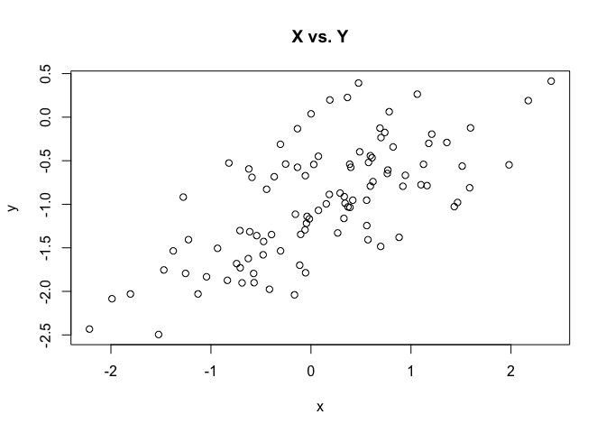

```r
#Plot x vs y
  plot(x,y,xlab="x",ylab="y",main="X vs. Y")
```

Appears to be a linear relationship between x and y.

### Part e

```r
#Fit the least squares linear model
  lm.fit1 <- lm(y~x)
  summary(lm.fit1)
```

```
##
## Call:
## lm(formula = y ~ x)
##
## Residuals:
##      Min       1Q   Median       3Q      Max
## -0.93842 -0.30688 -0.06975  0.26970  1.17309
##
## Coefficients:
##             Estimate Std. Error t value Pr(>|t|)
## (Intercept) -1.01885    0.04849 -21.010  < 2e-16 ***
## x            0.49947    0.05386   9.273 4.58e-15 ***
## ---
## Signif. codes:  0 '***' 0.001 '**' 0.01 '*' 0.05 '.' 0.1 ' ' 1
##
## Residual standard error: 0.4814 on 98 degrees of freedom
## Multiple R-squared:  0.4674, Adjusted R-squared:  0.4619
## F-statistic: 85.99 on 1 and 98 DF,  p-value: 4.583e-15
```

### Part f

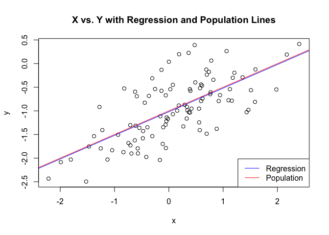

```r
#Plot x vs y with regression and population lines
  plot(x,y,xlab="x",ylab="y",main="X vs. Y with Regression and Population Lines")
  abline(lm.fit1,col="blue")
  abline(-1,0.5, col="red")
  legend("bottomright",c("Regression","Population"), col=c("blue","red"), lty=c(1,1))
```

### Part g

```r
#Fit regression with quadratic term
  lm.fit2 <- lm(y~x+I(x^2))
  summary(lm.fit2)
```

```
##
## Call:
## lm(formula = y ~ x + I(x^2))
##
## Residuals:
##      Min       1Q   Median       3Q      Max
## -0.98252 -0.31270 -0.06441  0.29014  1.13500
##
## Coefficients:
##             Estimate Std. Error t value Pr(>|t|)
## (Intercept) -0.97164    0.05883 -16.517  < 2e-16 ***
## x            0.50858    0.05399   9.420  2.4e-15 ***
## I(x^2)      -0.05946    0.04238  -1.403    0.164
## ---
## Signif. codes:  0 '***' 0.001 '**' 0.01 '*' 0.05 '.' 0.1 ' ' 1
##
## Residual standard error: 0.479 on 97 degrees of freedom
## Multiple R-squared:  0.4779, Adjusted R-squared:  0.4672
## F-statistic:  44.4 on 2 and 97 DF,  p-value: 2.038e-14
```

There is little evidence the addition of the quadratic term improves the fit of the model. The adjusted $R^2$ barely increases, and the coefficient on the quadratic term is not statistically significant.

### Part h

```r
#Generate data with less noise
  eps2 <- rnorm(100, mean=0,sd=sqrt(0.05))
  y2 <- -1 + (0.5*x) + eps2
#Fit the least squares linear model
  lm.fit3 <- lm(y2~x)
  summary(lm.fit3)
```

```
##
## Call:
## lm(formula = y2 ~ x)
##
## Residuals:
##      Min       1Q   Median       3Q      Max
## -0.65162 -0.10785 -0.01014  0.14518  0.59067
##
## Coefficients:
##             Estimate Std. Error t value Pr(>|t|)
## (Intercept) -0.99388    0.02341  -42.45   <2e-16 ***
## x            0.50473    0.02601   19.41   <2e-16 ***
## ---
## Signif. codes:  0 '***' 0.001 '**' 0.01 '*' 0.05 '.' 0.1 ' ' 1
##
## Residual standard error: 0.2324 on 98 degrees of freedom
## Multiple R-squared:  0.7936, Adjusted R-squared:  0.7915
## F-statistic: 376.7 on 1 and 98 DF,  p-value: < 2.2e-16
```

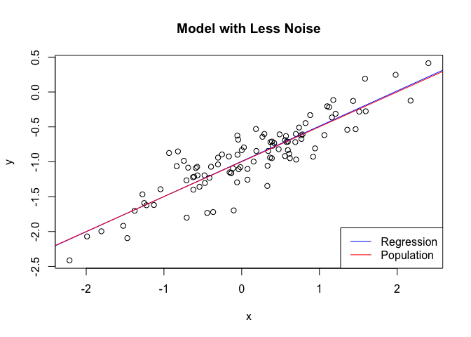

```r
#Plot x vs y with regression and population lines
  plot(x,y2,xlab="x",ylab="y",main="Model with Less Noise")
  abline(lm.fit3,col="blue")
  abline(-1,0.5, col="red")
  legend("bottomright",c("Regression","Population"), col=c("blue","red"), lty=c(1,1))
```

The regression line and coefficients are closer to the population values than in the original model.

### Part i

```r
#Generate data with more noise
  eps3 <- rnorm(100, mean=0)
  y3 <- -1 + (0.5*x) + eps3
#Fit the least squares linear model
  lm.fit4 <- lm(y3~x)
  summary(lm.fit4)
```

```
##
## Call:
## lm(formula = y3 ~ x)
##
## Residuals:
##      Min       1Q   Median       3Q      Max
## -2.51626 -0.54525 -0.03776  0.67289  1.87887
##
## Coefficients:
##             Estimate Std. Error t value Pr(>|t|)
## (Intercept)  -0.9423     0.1003  -9.397 2.47e-15 ***
## x             0.4443     0.1114   3.989 0.000128 ***
## ---
## Signif. codes:  0 '***' 0.001 '**' 0.01 '*' 0.05 '.' 0.1 ' ' 1
##
## Residual standard error: 0.9955 on 98 degrees of freedom
## Multiple R-squared:  0.1397, Adjusted R-squared:  0.1309
## F-statistic: 15.91 on 1 and 98 DF,  p-value: 0.000128
```

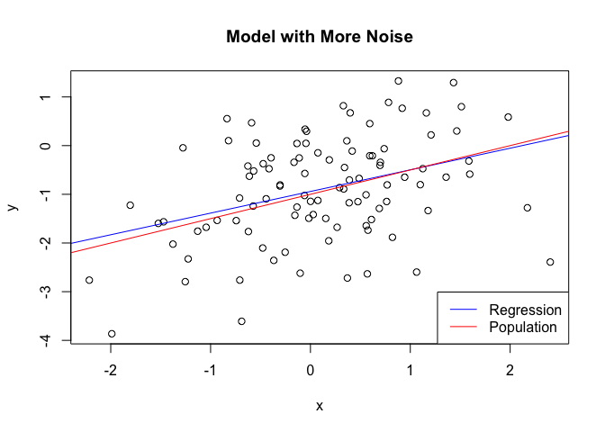

```r
#Plot x vs y with regression and population lines
  plot(x,y3,xlab="x",ylab="y",main="Model with More Noise")
  abline(lm.fit4,col="blue")
  abline(-1,0.5, col="red")
  legend("bottomright",c("Regression","Population"), col=c("blue","red"), lty=c(1,1))
```

The regression line and coefficients are less close to the population values than in the original model.

### Part j

```r
#Coefficient confidence intervals for original model
  confint(lm.fit1)
```

```
##                  2.5 %     97.5 %
## (Intercept) -1.1150804 -0.9226122
## x            0.3925794  0.6063602
```

```r
#Coefficient confidence intervals for model with less noise
  confint(lm.fit3)
```

```
##                  2.5 %     97.5 %
## (Intercept) -1.0403415 -0.9474188
## x            0.4531269  0.5563393
```

```r
#Coefficient confidence intervals for model with more noise
  confint(lm.fit4)
```

```
##                  2.5 %     97.5 %
## (Intercept) -1.1413399 -0.7433293
## x            0.2232721  0.6653558
```

The confidence intervals for the coefficients in the noisier data are larger than the confidence intervals for the coefficients in the original data. Likewise, the confidence intervals for the coefficients in the original data are larger than the confidence intervals for the coefficients in the less noisy data.